# Getting Started with canvasXpress in R

Isaac Neuhaus

2017-08-13

## Overview

*canvasXpress* was developed as the core visualization component for bioinformatics and systems biology analysis at Bristol-Myers Squibb. It supports a large number of [visualizations](http://www.canvasxpress.org/html/gallery.html)to display scientific and non-scientific data. *canvasXpress* also includes a simple and unobtrusive [user interface](http://www.canvasxpress.org/html/user-interface.html) to explore complex data sets, a sofisticated and unique mechanism to keep track of all user customization for [Reproducible Research](http://www.canvasxpress.org/html/reproducible-research.html) purposes, as well as an ‘out of the box’ broadcasting capability to synchronize selected data points in all *canvasXpress* plots in a page. Data can be easily sorted, grouped, transposed, transformed or clustered dynamically. The fully customizable mouse events as well as the zooming, panning and drag’n drop capabilities are features that make this library unique in its class.

*canvasXpress* can be now simply used within R at the console to generate conventional plots, in R-Studio or seamlessly embeded in [Shiny](http://shiny.rstudio.com) web applications. An full-fledged example of the *canvasXpress* library including the mouse events, zooming, and broadcasting capabilities is included in this package in the shiny directory. This *canvasXpress* R library was created with the htmlwidgets package.

## Examples

### Scatter 3D Plot

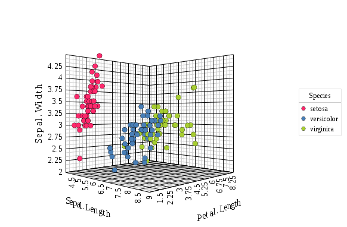

Scatter3D

```r
data <- t(iris[,1:4])
varAnnot <- as.matrix(iris[,5])
colnames(varAnnot) <- "Species"
canvasXpress(t(data), varAnnot=varAnnot, graphType='Scatter3D', colorBy='Species')
```

### Scatter 2D Matrix Plot

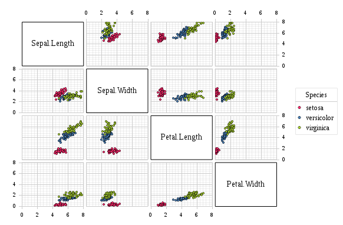

Scatter2DMatrix

```r
data <- t(iris[,1:4])
varAnnot <- as.matrix(iris[,5])
colnames(varAnnot) <- "Species"
canvasXpress(t(data), varAnnot=varAnnot, scatterPlotMatrix=1, colorBy='Species')
```

### Boxplot

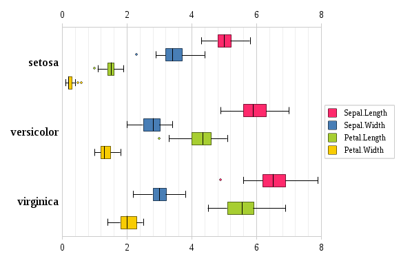

Boxplot

```r
data <- t(iris[,1:4])
smpAnnot <- as.matrix(iris[,5])
colnames(smpAnnot) <- "Species"
canvasXpress(data, smpAnnot=smpAnnot, graphType='Boxplot', groupingFactors=list('Species'))
# or
canvasXpress(data, smpAnnot=smpAnnot, graphType='Boxplot', afterRender=list(list('groupSamples', list('Species'))))
```

### Heatmap

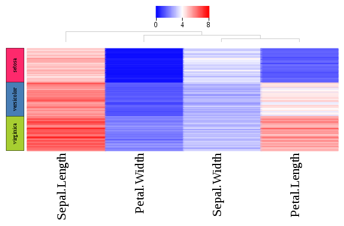

Heatmap

```r
data <- t(iris[,1:4])
smpAnnot <- as.matrix(iris[,5])
colnames(smpAnnot) <- "Species"
canvasXpress(data, smpAnnot=smpAnnot, graphType='Heatmap', smpOverlays=list('Species'), variablesClustered=TRUE, showSampleNames=FALSE)
```

### Four-way Venn Diagram

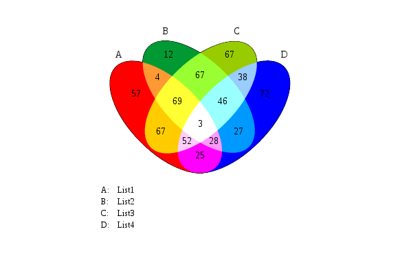

Venn

```r
vennData <- data.frame(A=57, B=12, C=67, D=72, AB=4, AC=67, AD=25, BC=67, BD=27, CD=38, ABC=69, ABD=28, ACD=52, BCD=46, ABCD=3)
canvasXpress(vennData=vennData, graphType='Venn', vennGroups=4, vennLegend=list(A="List1", B="List2", C="List3", D="List4"))
```

## Additional Information

Additional information and many examples with the JavaScript *canvasXpress* library can be found [here](http://www.canvasxpress.org).